# Week 3 - Weird R Packages

2/18/2020

# The schrute package

One fun thing about R is that there are just a whole bunch of strange packages that people have created and made accessible to others. One example is the **schrute** package, which contains the scripts for every episode of The Office (U.S. version). Below is a quick glance at what variables are in the data. Check out the help menu or use View() to see more.

```r
library(schrute)
data("theoffice")
names(theoffice)
```

```
## [1] "index"            "season"           "episode"          "episode_name"
## [5] "director"         "writer"           "character"        "text"
## [9] "text_w_direction"
```

The package is meant to be used to practice text mining. Check out the help file for the package to learn more about this. In the meantime, we can explore the package a bit to learn things about which characters talk most and how that varies over season. I’ll make use of the **dplyr** and **ggplot2** packages, which we will see much more of soon.

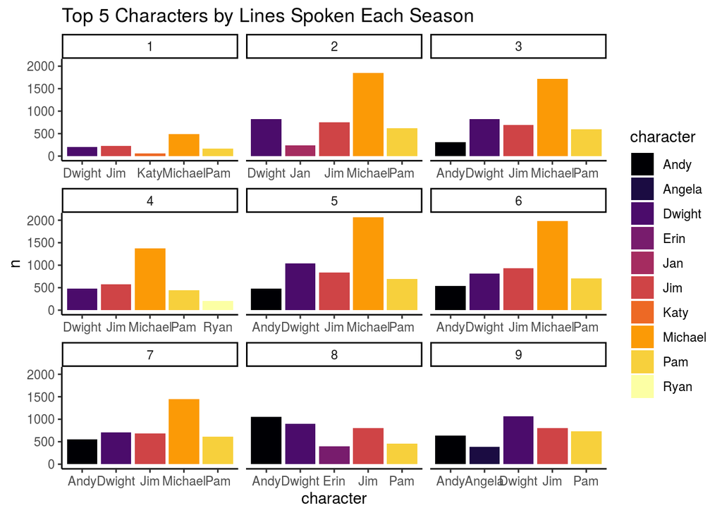

```r
library(dplyr)
library(ggplot2)

# Convert season and episode variables to numeric
theoffice <- mutate(theoffice, season = as.numeric(season),
                    episode = as.numeric(episode))

# Count how often each character speaks during each season
characters <- group_by(theoffice, season, character) %>%
  count() %>%
  arrange(season, desc(n)) %>%
  ungroup()

# Create a graph showing the top 5 by season
ggplot(top_n(group_by(characters, season), 5), aes(x = character, y = n)) +
  geom_col(aes(fill = character)) +
  facet_wrap(.~season, scales = "free_x") +
  scale_fill_viridis_d(option = "B") +
  theme_classic() +
  labs(title = "Top 5 Characters by Lines Spoken Each Season")
```

# The emojifont pacakge

Let’s try adding in another package as well. The character Angela on the show has cats that she talks about frequently. Let’s make a graph showing how often she speaks each season and then use a package called **emojifont** to display the points on the graph as cats.

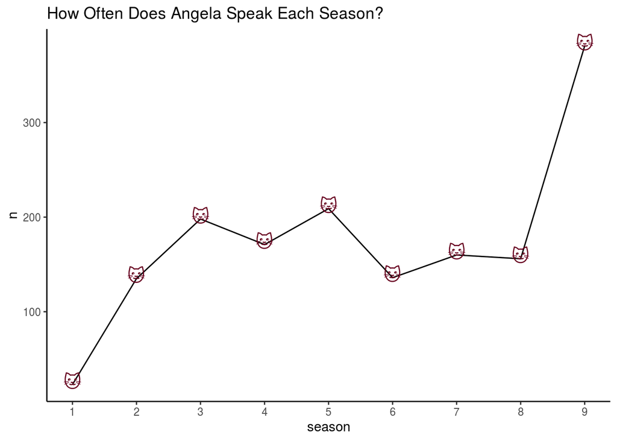

```r
library(emojifont)
angela <- filter(characters, character == "Angela")

ggplot(angela, aes(x = season, y = n)) +
  geom_line() +
  geom_emoji('cat', x = angela$season, y = angela$n, size = 5) +
  scale_x_continuous(breaks = 1:9) +
  labs(title = "How Often Does Angela Speak Each Season?") +
  theme_classic()
```

As an extra exercise, you could explore using the sample_n() function from the **dplyr** pacakge to generate random quotes from a particular episode, character, or season.